# EP05-respuesta-equipo-07.Rmd

Equipo 07

## Enlace Conversacion con la IA:

(en caso de que hayan errores pa abrir el link, la conversación fue enviada como pdf al correo del profesor el jueves 22/10)

https://gemini.google.com/share/d/1ZtoPjSN_RDLVQPfSavsoV-dQRUZT4LLK?usp=drive_link

# Aclaración entrega final

Leyendo las instrucciones antes de entregar, nos dimos cuenta que la sección de Datos en uvirtual dice “En cada invierno, los días se seleccionaron aleatoriamente, asegurando una distancia de entre 4 y 7 días entre observaciones para que puedan considerarse independientes.”

Esto claramente cambia la forma de ver la pregunta 1, que antes fue analizada con muestras correlacionadas, pero ahora será abordada como con muestras independientes.

## Pregunta 1

En la estación Las Condes, ¿la concentración diaria promedio de MP2,5 fue la misma en los inviernos de 2018, 2019, 2020, 2022 y 2023? En particular, interesa saber si el invierno de 2020, el de las cuarentenas por la pandemia, se diferenció del promedio de los demás inviernos. Si filtraron bien los datos, deberían obtener: 2018, n = 22 y media 25,91; 2019, n = 21 y media 24,05; 2020, n = 23 y media 18,35; 2022, n = 23 y media 28,91; 2023, n = 25 y media 23,96 [µg/m³N].

Prueba a Ocupar: Procedimiento Omnibus: ANOVA para muestras independientes

Justificacion: Ya que por cada grupo hay una sola medición

Hipotesis:

$H_0$:: En la estación Las Condes, la concentración diaria promedio de MP2,5 fue la misma en los inviernos de 2018, 2019, 2020, 2022 y 2023.

$H_A$: En la estación Las Condes, la concentración diaria promedio de MP2,5 fue diferente en al menos uno de los inviernos.

Condiciones:

1. Escala: La Variable Dependiente es continua con un cero verdadero
2. Independencia: Las observaciones son elegias aleatoriamente en la poblacion en los distintos años. segun enunciado se puedes considerar que las observaciones son independientes, ya que los días se seleccionaron aleatoriamente, asegurando una distancia de entre 4 y 7 días entre observaciones.
3. Normalidad: Notemos que los p-value son mayores que alfa (0,05) entonces todos tienen una distribucion normal
4. Homocedasticidad: Varianza Iguales, Se verifica aplicando la prueba de Levene ($p > 0,05$).

```
##        fecha invierno         estacion mp25
## 1 2018-05-18     2018      Cerro Navia   47
## 2 2018-05-18     2018       La Florida   29
## 3 2018-05-18     2018       Las Condes   29
## 4 2018-05-18     2018 Parque O'Higgins   35
## 5 2018-05-18     2018         Pudahuel   41
## 6 2018-05-18     2018      Puente Alto   22
```

```
## Datos filtrados para la estación Las Condes y los inviernos seleccionados
```

```
##        fecha invierno   estacion mp25
## 1 2018-05-18     2018 Las Condes   29
## 2 2018-05-22     2018 Las Condes   29
## 3 2018-05-26     2018 Las Condes   49
## 4 2018-06-02     2018 Las Condes   31
## 5 2018-06-06     2018 Las Condes   18
## 6 2018-06-13     2018 Las Condes   23
```

```
##
## Resultados de la prueba de Shapiro-Wilk para normalidad por invierno
```

```
## # A tibble: 5 × 4
##   invierno variable statistic     p
##   <fct>    <chr>        <dbl> <dbl>
## 1 2018     mp25         0.962 0.530
## 2 2019     mp25         0.939 0.210
## 3 2020     mp25         0.947 0.250
## 4 2022     mp25         0.961 0.485
## 5 2023     mp25         0.947 0.209
```

```
##
## Resultados de la prueba de Levene para igualdad de varianzas por invierno
```

```
## # A tibble: 1 × 4
##     df1   df2 statistic     p
##   <int> <int>     <dbl> <dbl>
## 1     4   109     0.668 0.616
```

```
##
## Resultados de la prueba ANOVA para muestras independientes
```

```
## ANOVA Table (type II tests)
##
##     Effect DFn DFd     F     p p<.05  ges
## 1 invierno   4 109 2.682 0.035     * 0.09
```

```
##
## Resultados de la prueba T para muestras independientes comparando 2020 con el promedio de los demás años
```

```
##
##  Two Sample t-test
##
## data:  mp25 by ifelse(invierno == 2020, "2020", "Resto de años")
## t = -2.7951, df = 112, p-value = 0.006107
## alternative hypothesis: true difference in means between group 2020 and group Resto de años is not equal to 0
## 95 percent confidence interval:
##  -12.569613  -2.141328
## sample estimates:
##          mean in group 2020 mean in group Resto de años
##                    18.34783                    25.70330
```

```
##
## Resultados de las comparaciones por pares con corrección de Holm
```

```
## # A tibble: 4 × 9
##   .y.   group1 group2    n1    n2       p p.signif   p.adj p.adj.signif
## * <chr> <chr>  <chr>  <int> <int>   <dbl> <chr>      <dbl> <chr>
## 1 mp25  2020   2018      23    22 0.0266  *        0.0798  ns
## 2 mp25  2020   2019      23    21 0.0970  ns       0.176   ns
## 3 mp25  2020   2022      23    23 0.00194 **       0.00776 **
## 4 mp25  2020   2023      23    25 0.0879  ns       0.176   ns
```

Para evaluar si el invierno de 2020 (año de cuarentenas) presentó diferencias respecto a los demás inviernos en la estación Las Condes, se realizó una prueba t de Student para muestras independientes, comparando la concentración media de MP2.5 de 2020 con el promedio agrupado de los inviernos de 2018, 2019, 2022 y 2023. Los resultados mostraron que la media de 2020 fue de 18,35 µg/m³N, significativamente inferior al promedio de los demás inviernos, de 25,70 µg/m³N (*t*(112) = −2,80; *p* = 0,0061). Además, el ANOVA mostró diferencias estadísticamente significativas entre las medias de los cinco inviernos (*F*(4,109) = 2,682; *p* = 0,035). Las comparaciones post hoc con ajuste de Holm identificaron una diferencia significativa únicamente entre 2020 y 2022 (*p* ajustado = 0,00776); las diferencias entre 2020 y los inviernos de 2018, 2019 y 2023 no fueron significativas tras el ajuste. En conjunto, los resultados indican que la concentración media de MP2.5 durante el invierno de 2020 fue significativamente menor que el promedio agrupado de los demás inviernos, aunque las comparaciones por pares solo evidenciaron una diferencia significativa respecto a 2022.

## Pregunta 2

En el invierno de 2022, ¿la concentración diaria promedio de MP2,5 fue la misma en las estaciones Parque O’Higgins, Pudahuel y Quilicura? En particular, interesa comparar cada una de las otras estaciones con la de Parque O’Higgins. Si filtraron bien los datos, deberían obtener: Parque O’Higgins, n = 23 y media 43,74; Pudahuel, n = 23 y media 44,17; Quilicura, n = 23 y media 45,00 [µg/m³N].

Prueba a Ocupar: Procedimiento Omnibus: ANOVA para muestras independientes.

Procedimiento Post-hoc: Comparaciones por pares mediante prueba t de Student, utilizando la corrección de Bonferroni y estableciendo Parque O’Higgins como grupo de referencia.

Justificación: Por cada grupo hay una sola medición y se busca comparar el promedio de una variable numérica continua (concentración de MP2,5) entre tres grupos ($k=3$). En cuanto al procedimiento post-hoc, la pregunta señala explícitamente que solo interesa comparar cada una de las otras estaciones con la de Parque O’Higgins, es decir hacer un contraste contra un grupo de referencia.

Hipotesis:

$H_0$:En el invierno de 2022, la concentración diaria promedio de MP2,5 fue la misma en las estaciones Parque O’Higgins, Pudahuel y Quilicura.

$H_A$: En el invierno de 2022, la concentración diaria promedio de MP2,5 fue diferente en al menos una de las estaciones.

Condiciones:

1. Escala: La variable Dependiente es continua con un cero verdadero.
2. Independencia: segun enunciado se puedes considerar que las observaciones son independientes, ya que los días se seleccionaron aleatoriamente, asegurando una distancia de entre 4 y 7 días entre observaciones.
3. Normalidad: Se asume que las poblaciones de origen siguen una distribución normal. Esto se verifica visualmente con los gráficos Q-Q y numéricamente en la prueba de Shapiro-Wilk, ya que todos los grupos obtienen un valor $p > 0,05$
4. Homocedasticidad: Varianza Iguales. Se verifica aplicando la prueba de Levene ($p > 0,05$).

```
## Datos filtrados para el invierno de 2022 y estaciones seleccionadas
```

```
##        fecha invierno         estacion mp25
## 1 2022-05-04     2022 Parque O'Higgins   35
## 2 2022-05-04     2022         Pudahuel   46
## 3 2022-05-04     2022        Quilicura   42
## 4 2022-05-11     2022 Parque O'Higgins   56
## 5 2022-05-11     2022         Pudahuel   50
## 6 2022-05-11     2022        Quilicura   59
```

```
##
## Resumen de medias y tamaños de muestra por estación
```

```
## # A tibble: 3 × 3
##   estacion             n media
##   <fct>            <int> <dbl>
## 1 Parque O'Higgins    23  43.7
## 2 Pudahuel            23  44.2
## 3 Quilicura           23  45
```

```
##
## Gráfico QQ para verificar normalidad por estación
```

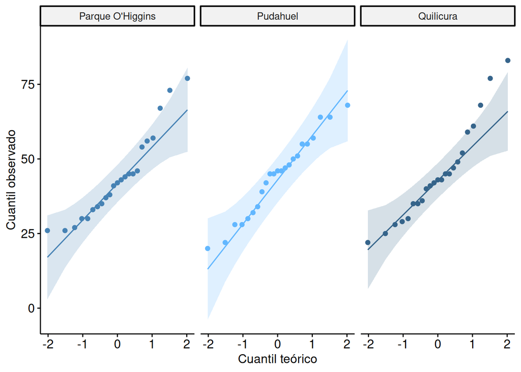

```
##
## Resultados de la prueba de Shapiro-Wilk para normalidad por estación
```

```
## # A tibble: 3 × 4
##   estacion         variable statistic      p
##   <fct>            <chr>        <dbl>  <dbl>
## 1 Parque O'Higgins mp25         0.915 0.0513
## 2 Pudahuel         mp25         0.969 0.664
## 3 Quilicura        mp25         0.934 0.135
```

```
##
## Resultados de la prueba de Levene para homocedasticidad
```

```
## # A tibble: 1 × 4
##     df1   df2 statistic     p
##   <int> <int>     <dbl> <dbl>
## 1     2    66    0.0816 0.922
```

```
##
## Prueba Ómnibus ANOVA para muestras independientes
```

```
## ANOVA Table (type II tests)
##
##     Effect DFn DFd     F     p p<.05   ges
## 1 estacion   2  66 0.044 0.957       0.001
```

```
##
## Resultados del procedimiento post-hoc (comparaciones múltiples)
```

```
## # A tibble: 2 × 9
##   .y.   group1           group2       n1    n2     p p.signif p.adj p.adj.signif
## * <chr> <chr>            <chr>     <int> <int> <dbl> <chr>    <dbl> <chr>
## 1 mp25  Parque O'Higgins Pudahuel     23    23 0.920 ns           1 ns
## 2 mp25  Parque O'Higgins Quilicura    23    23 0.771 ns           1 ns
```

```
##
## Comparaciones por pares con la corrección de Holm
```

```
##
##  Pairwise comparisons using t tests with pooled SD
##
## data:  datos_filtrados_independientes$mp25 and datos_filtrados_independientes$estacion
##
##           Parque O'Higgins Pudahuel
## Pudahuel  1                -
## Quilicura 1                1
##
## P value adjustment method: holm
```

A raiz de los resultados para la prueba de Anova, no correspondería hacer un procedimiento post-hoc, ya que el valor p es mayor a 0.05, lo que indica que no hay diferencias significativas entre las estaciones. Sin embargo, se realizaron las comparaciones por pares para cumplir con la solicitud del enunciado.

En las comparaciones por pares con la corrección de Bonferroni, no se encontraron diferencias estadísticamente significativas entre Parque O’Higgins y Pudahuel, ni entre Parque O’Higgins y Quilicura (p.adj=1).

Por otro lado, al realizar todas las comparaciones por pares con la corrección de Holm, tampoco se encontraron diferencias estadísticamente significativas entre ninguna de las estaciones. Esto coincide con los resultados obtenidos mediante Bonferroni en las dos comparaciones compartidas. La diferencia es que Holm incluye también la comparación entre Pudahuel y Quilicura, además de utilizar un método de ajuste distinto.

En conclusión, con un nivel de significación de 0,05, no se encontró evidencia estadísticamente significativa de diferencias en la concentración diaria promedio de MP2,5 durante el invierno de 2022 entre las estaciones Parque O’Higgins, Pudahuel y Quilicura.